# Phosphorus Budgets for SJRE

Kenneth Anderson

2023-10-20

## H0: ODNR Budgets:

ODNR makes budgets for P reduction in potential wetlands using the following method:

1. Put the lat/long of the outlet of the wetland into USGS Stream Stats to get the drainage area of the wetland (convert to acres)
2. Based on the size of the wetland correct for the amount of the drainage the wetland interacts with
1. 0-99 acres: 95%
2. 100-999 acres: 75%
3. 1,000-9,999 acres: 25%
4. 10,000-99,999 acres: 10%
5. 100,000-999,999 acres: 1%
6. 1,000,000 acres +: 0.5%

```r
# Drainage Area from Stream Stats
DA = 48
# Treated drainage area (corrected for drainage size)
tDA = if(DA <= 99){DA*0.95} else if(DA >= 100 & DA <= 999){DA*0.75} else if(DA >= 1000 & DA <= 9999){DA*0.25} else if(DA >= 10000 & DA <= 99999){DA*0.1} else if(DA >= 100000 & DA <= 999999){DA*0.01} else if(DA > 100000000){DA*0.005}
# units = acres
print(tDA)
```

```
## [1] 45.6
```

3. Estimate P loading rate using the USGS SPARROW model (units are pounds P / year) based on total drainage area treated (calculated in step 2)

```r
# P Loading Rates for Ohio from USGS SPARROW:
# HUC-8 Drainage basin ID
HUC8 = c(4100001,4100008,4100009,4100010,4100011,4100003,4100005,5120101,5040006,5090202,4120200,4120101,4100007,4100006,5040001,5080001,5060001,4100014,4110001,4110002,4110003,4110004)
# Total phosphorus yield for each basin (kg/km^2/year)
TPyieldkgkm=c(75.2,131,129,83.9,140,114,106,293,206,216,0,123,152,114,134,201,209,149,179,249,245,109)
loading=data.frame(HUC8,TPyieldkgkm)
# correct to lbs/acre/year from kg/km^2/year:
corr=112.0850759
loading$TPyield = loading$TPyieldkgkm/corr

# select the HUC-8 basin that the wetland is a part of
loadSJREHUC = loading$TPyield[loading$HUC8 == 4100003]
# multiply by the treated drainage area from step 2
loadSJRE = loadSJREHUC * tDA
# units = lbs / year
print(loadSJRE)
```

```
## [1] 46.37906
```

4. Estimate P removal based on literature (as proposed by TetraTech; units: pounds P/ acre / year):
1. Low estimate: 18% removal of P loading
2. Hybrid estimate: 64% removal of P loading
3. High estimate: 78% of P loading

```r
# P Removal Rates:
low = loadSJRE*0.18
hybrid = loadSJRE*0.64
high = loadSJRE*0.78

# units = lbs/year
print(low)
```

```
## [1] 8.34823
```

```r
print(hybrid)
```

```
## [1] 29.6826
```

```r
print(high)
```

```
## [1] 36.17566
```

4b. For floodplain wetlands estimates are based on constants from Noe et al. 2019: 3.2 pounds P/ acre / year removal

### *ASSUMPTIONS IN ODNR BUDGETS:*

Not that many, but big assumptions  
1. Drainage area is accurate (it’s not)  
2. SPARROW gives an accurate measurement of P loading  
3. Literature estimates of loading are accurate  
* Honestly this probably isn’t the worst assumption if only because their estimates are so wide ranging.  
4. Seasonal variation does not matter to whoever is looking for this budget.  
5. Annual variation does not play a major role in phosphorus loading, or retention, or hydrologic dynamics.

## H1: Main flow path budget calculating Runoff from Rainfall

Calculate drainage area and treated drainage area using digital elevation models:

```r
# Drainage Area calculated by Bishwodeep using Digital Elevation Model (DEM)
tDA = 103.32 # units = acres CHECK THIS WITH BISHWODEEP
# convert tDA to m^2
tDAm2=tDA*4046.86
# units = m^2
print(tDAm2)
```

```
## [1] 418121.6
```

Then we import data on precipitation from the sensor network and from the nearby weather station at Ft. Wayne (from WeatherUnderground) which we will use to fill in our rainfall data.

```r
setwd("C:/Users/kande120/OneDrive - Kent State University/Phosphorus Budgets/SJRE/Data")
raindata<-read.csv("SJREsensors.csv")
setwd("C:/Users/kande120/OneDrive - Kent State University/Phosphorus Budgets/FORB/Data")
raindata_wayne<-read.csv("Ftwaynerainfall.csv")

# make it recognize that it's a date-time value
raindata = mutate(raindata, datetime = as.POSIXct(datetime, format = "%Y-%m-%d %H:%M:%S"))
dayrain_wayne = mutate(raindata_wayne, datetime = as.POSIXct(datetime, format = "%m/%d/%Y")) # rainfall data is in inches

# Here we will aggregate our rainfall values (just for the sensor data, the WeatherUnderground data is already the daily sum) so we have a sum of rainfall for each day
DF2 <- transform(raindata, Date = as.Date(datetime))
dayrain=aggregate(precipaccum ~ Date, DF2, sum) # rainfall data is in mm
```

We will calculate the runoff that flows through the wetland during rain events based on some information about soil properties.

$$Q=\begin{cases}
0 \text{ for } P \le I_a\\
{(P-I_a)^2 \over P-I_a+S} \text{ for } P > I_a
\end{cases}$$

where:  
Q = runoff (inches)  
P = rainfall (inches)  
S = potential maximum soil moisture retention after runoff begins (inches)  
I_a = initial abstraction (inches; this is the amount of rainfall needed for runoff to occur)

The runoff curve (CN) is used to calculate S
$$S = {1000 \over CN} -10$$
We will assume that:
$$I_a = 0.2S$$
as a standard correction. (See here https://onlinelibrary.wiley.com/doi/10.1111/j.1752-1688.2006.tb04481.x for discussion of whether that is a good correction but we’re going to power through with it)

```r
# Start out by calculating S (inches)
CN=85
S = (1000/CN)-10
# Calculate I (inches)
Ia = 0.2*S
# convert rain to inches/day
dayrain$precip_in = dayrain$precipaccum/25.4
# caculate runoff (inches) for each day in the dataset
dayrain$Q = ifelse(dayrain$precip_in<=Ia, 0, ((dayrain$precip_in-Ia)^2)/(dayrain$precip_in-Ia+S))
# convert back to meters
dayrain$Qm = dayrain$Q * 0.0254
# scale up to the entire drainage area
dayrain$Qmfull=tDAm2*dayrain$Qm
# convert discharge to liters
dayrain$QL = dayrain$Qmfull * 1000
# Sum up data to get monthly values
library(lubridate)
library(tidyverse)
dayrain$Date=as.POSIXct(dayrain$Date,format="%Y-%m-%d")
# Summarize the dataset by month and year
monthrain=dayrain %>% mutate(Month=month(Date,label = T),Year=year(Date)) %>%
  group_by(Year,Month) %>% summarise(QL=sum(QL,na.rm=T))
```

Now we add in the monthly measurements of Phosphorus concentrations to calculate P loading. We’ll start with pool B.

```r
# Add in the P dataset (units here are mg/L for TP)
setwd("C:/Users/kande120/OneDrive - Kent State University/Phosphorus Budgets/SJRE/Data")
Pdata<-read.csv("SJRE P Budget Full inletsandoutlets.csv")

# subset out event sampling
Pdata<- subset(Pdata, Sampling == "baseflow")
# These are the first 6 rows to give you an idea what the datatable looks like
head(Pdata)
```

```
##         Date Year Month Day month Sampling X1_Inlet_N.TP X2_Inlet_NW.TP
## 1  8/13/2021 2021   Aug  13     8 baseflow         0.206          0.230
## 2 10/11/2021 2021   Oct  11    10 baseflow            NA             NA
## 3   3/8/2022 2022   Mar   8     3 baseflow         0.063          0.073
## 4   6/8/2022 2022   Jun   8     6 baseflow            NA             NA
## 5  7/20/2022 2022  July  20     7 baseflow         0.037          0.123
## 6   8/2/2022 2022   Aug   2     8 baseflow         0.131          0.418
##   X3_Inlet_NE.TP X18_Inlet_ditchExt.TP.OR.upstream17 X5_inlet_poolB
## 1          0.352                                  NA         0.0680
## 2             NA                               0.232             NA
## 3          0.054                                  NA         0.0320
## 4             NA                                  NA         0.2745
## 5          0.089                                  NA         0.4010
## 6          0.105                                  NA         0.4120
##   X5_Outlet_poolB X15_Outlet_swale X17_Outlet_ditch.TP X19_River X1_Inlet_N.DRP
```

[output cut: 27 more lines]

```r
# merge the datasets
total <- merge(monthrain,Pdata,by=c("Month","Year"),all=TRUE)

# averaging the various inflows
total$inflowTP <- rowMeans(total[c('X1_Inlet_N.TP', 'X2_Inlet_NW.TP','X3_Inlet_NE.TP','X18_Inlet_ditchExt.TP.OR.upstream17')], na.rm=TRUE)
# Now calculate the average outflow TP
total$outflowTP <- rowMeans(total[c('X15_Outlet_swale', 'X17_Outlet_ditch.TP')], na.rm=TRUE)
# Measure the mass of P entering the wetland (units = mg P/year)
total$Pin=total$inflowTP*total$QL
# calculate the total mass of P exiting the wetland (units = mg P/year)
total$Pout=total$outflowTP*total$QL
# Convert to lbs P/year
total$Pinlb=total$Pin/453592
total$Poutlb=total$Pout/453592
# calculate the amount of P removed
total$Premoved=total$Pinlb-total$Poutlb
Removal = sum (total$Premoved,na.rm=T)
# This is the removal of P over the course of the 3 months included in this data
print(Removal)
```

```
## [1] 21.36732
```

```r
# We can make a rough annual estimate by just multiplying by 4:
AnnRemoval=Removal*4
print(AnnRemoval)
```

```
## [1] 85.46928
```

```r
# Calculate percent removal
total$percentP=total$Premoved/total$Pinlb
percentRemoval = mean (total$percentP,na.rm=T)
print(percentRemoval)
```

```
## [1] 0.9648419
```

Now we can start to look at how to deal with the months with rainfall data, but no phosphorus data

```r
# make a dataset for only 2023
total23 <- subset(total, Year == "2023")
# clean up any repeat months
total23 <- total23 %>% group_by(Month) %>% summarise(across(c(Year, QL, inflowTP, outflowTP,Pin, Pout, Pinlb, Poutlb,Premoved,percentP), mean))
print(total23)
```

```
## # A tibble: 12 × 11
##    Month  Year       QL inflowTP outflowTP      Pin    Pout  Pinlb   Poutlb
##    <ord> <dbl>    <dbl>    <dbl>     <dbl>    <dbl>   <dbl>  <dbl>    <dbl>
##  1 Jan    2023      NA    0.257       0.05      NA      NA   NA     NA
##  2 Feb    2023      NA    0.167       0.31      NA      NA   NA     NA
##  3 Mar    2023      NA    0.0733    NaN         NA      NA   NA     NA
##  4 Apr    2023      NA    0.05        0.31      NA      NA   NA     NA
##  5 May    2023      NA    0.453       0.3       NA      NA   NA     NA
##  6 Jun    2023  574068.   0.85        0.02  487958.  11481.   1.08   0.0253
##  7 Jul    2023 7362128.   1.19        0.07 8760932. 515349.  19.3    1.14
##  8 Aug    2023  573956.   1.73        0.04  992944.  22958.   2.19   0.0506
##  9 Sep    2023 1697816. NaN         NaN        NaN     NaN  NaN    NaN
## 10 Oct    2023 2490829. NaN         NaN        NaN     NaN  NaN    NaN
## 11 Nov    2023  136320. NaN         NaN        NaN     NaN  NaN    NaN
## 12 Dec    2023  155300. NaN         NaN        NaN     NaN  NaN    NaN
## # ℹ 2 more variables: Premoved <dbl>, percentP <dbl>
```

Now we have a dataset with each month of the year where some months have phosphorus data but no discharge data, and some months have discharge data but no phoshorus data. Lets do the easy part first and fill in missing discharge data with rainfall data from Ft. Wayne:

```r
# Now we come back to our previously loaded Fort Wayne Dataset
# don't need to convert rain to inches/day, but lets name it so our old code still works
# calculate runoff (inches) for each day in the dataset
dayrain_wayne$Q = ifelse(dayrain_wayne$precipaccum_in<=Ia, 0, ((dayrain_wayne$precipaccum_in-Ia)^2)/(dayrain_wayne$precipaccum_in-Ia+S))
# convert back to meters
dayrain_wayne$Qm = dayrain_wayne$Q * 0.0254
# scale up to the entire drainage area
dayrain_wayne$Qmfull=tDAm2*dayrain_wayne$Qm
# convert discharge to liters
dayrain_wayne$QL = dayrain_wayne$Qmfull * 1000
# Sum up data to get monthly values
library(lubridate)
library(tidyverse)
dayrain_wayne$Date=as.POSIXct(dayrain_wayne$datetime,format="%Y-%m-%d")
# Summarize the dataset by month and year
monthrainft=dayrain_wayne %>% mutate(Month=month(Date,label = T),Year=year(Date)) %>%
  group_by(Year,Month) %>% summarise(QL=sum(QL,na.rm=T))
```

```r
# first we need to cut out the rows from the Ft. Wayne dataset where we already have rainfall data from the sensor network:
# As a note to future me: I am not including the June data from Ft. Wayne because EVEN THOUGH we only have 3 days of rainfall from the sensor network for June, those 3 days had MORE DISCHARGE THAN WAS AT FT. WAYNE FOR THE WHOLE MONTH. So from that we can assume the rest of June was pretty dry and our estimate even with only 3 days is better than Ft. Wayne for June. It's not as if it's less than the 3 days worth.
monthrainft = subset(monthrainft, Month == "Jan" | Month == "Feb" | Month == "Mar" | Month == "Apr" | Month == "May")

# now we need to slot in the Ft. Wayne data into our main dataset
totalplus23 <- merge(total23,monthrainft,by=c("Month","Year","QL"),all=TRUE)
total23final <- totalplus23 %>% group_by(Month) %>% summarise(across(c(Year, QL, inflowTP, outflowTP,Pin, Pout, Pinlb, Poutlb,Premoved,percentP), mean, na.rm=TRUE))
```

Now we have discharge estimates for all months of 2023 (some sensor data, some data from the Ft. Wayne Weather Station). We have phosphorus concentrations when water was available to be collected during monthly sampling. Our next steps are to 1. calculate loads and retention based on discharge from the Ft. Wayne data, 2. Estimate load and retention based on high and low values for months with missing concentration data.

```r
# first make all NaNs into NAs
total23final <- total23final %>% mutate_all(~ifelse(is.nan(.), NA, .))

# percent phosphorus retention for each month
total23final$percentP=(total23final$inflowTP-total23final$outflowTP)/total23final$inflowTP
# We have one date where we have input data, but not output data. We're going to assume that it's the average retention of the previous and the prior month:
# the previous month is -0.86% retention, and the next month is -5.2% retention. The inflow concentration is 0.07333333
mean(c(-0.86,-5.2))
```

```
## [1] -3.03
```

```r
-3.03*0.073
```

```
## [1] -0.22119
```

```r
# replace the month in question (March 2023)
total23final$outflowTP=ifelse(test = total23final$Month == "3" & total23final$Year == "2023", yes = 0.22, no = total23final$outflowTP)

# Measure the mass of P entering the wetland (units = mg P/year)
total23final$Pin=total23final$inflowTP*total23final$QL
# calculate the total23final mass of P exiting the wetland (units = mg P/year)
total23final$Pout=total23final$outflowTP*total23final$QL
# Convert to lbs P/year
total23final$Pinlb=total23final$Pin/453592
total23final$Poutlb=total23final$Pout/453592
# calculate the amount of P removed
total23final$Premoved=total23final$Pinlb-total23final$Poutlb
# calculate the % P removed
total23final$percentP=total23final$Premoved/total23final$Pinlb

# calculate the average percent removal
mean(total23final$percentP,na.rm=TRUE)
```

```
## [1] -0.5027555
```

```r
# calculate a percent removal by the LOAD of the wetland (this highlights the importance of load in calculating percent removal)
sum(total23final$Premoved,na.rm=TRUE)/sum(total23final$Pinlb,na.rm=TRUE)
```

```
## [1] 0.5029045
```

We can estimate the remaining months by estimating a low and a high value for P loading and P retention.  
We have discharge data for all months, so we don’t want to just estimate loading, when we can estimate concentration instead:

```r
# our low estimate is the lowest concentration we saw:
lowPcon = min(total23final$inflowTP,na.rm = TRUE)
# our high estimate is the highest concentration we saw:
highPcon= max(total23final$inflowTP,na.rm = TRUE)

# then we can estimate the low end of % retention
lowPper = min(total23final$percentP,na.rm = TRUE)
# and then the high end of % retention
highPper = max(total23final$percentP,na.rm = TRUE)


# now calculate P load and retention using these concentrations to estimate the high and low end of P removal by the wetland:

# first for the low estimate
total23final$Premovedlow=ifelse(test = is.na(total23final$Premoved) , yes = total23final$QL*lowPcon/453592*lowPper, no = total23final$Premoved)
# then for the high estimate
total23final$Premovedhigh=ifelse(test = is.na(total23final$Premoved) , yes = total23final$QL*highPcon/453592*highPper, no = total23final$Premoved)

# Now we can sum up our full months:
lowRemoval = sum (total23final$Premovedlow,na.rm=T)
highRemoval = sum (total23final$Premovedhigh,na.rm=T)
print(lowRemoval)
```

```
## [1] 16.46062
```

```r
print(highRemoval)
```

```
## [1] 35.72136
```

Now lets plot it out real quick to see the annual variation:

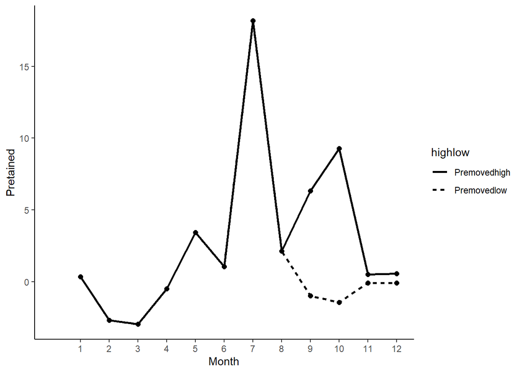

```r
# lets prune our dataframe to only what we're interested in:
totalplot = subset(total23final, select = c(Month,Premovedlow,Premovedhigh) )

# lets put our dataframe into the tall format so we can plot it more easily:
dfplots = totalplot %>%
    gather(highlow,Pretained, Premovedlow, Premovedhigh)

# now make the plot

ggplot(data=dfplots, aes(x=Month, y=Pretained, group=highlow)) +
  geom_line(aes(linetype=highlow),size=1)+
  geom_point(size=2)+
  scale_x_continuous(name="Month", breaks = 1:12, limits=c(0, 12))+
  theme_classic()
```

### *ASSUMPTIONS IN BUDGET:* 1. Drainage area is accurate  
2. P isn’t lost through groundwater  
3. Baseflow P reduction = storm flow P reduction  
4. Summer P measurements represent annual averages (they don’t)  
5. The average of inflow concentrations represents average P concentration entering the wetland (This likely is NOT true because the amounts of water flowing through each input is different)  
6. Pool B represents the whole wetland

As one last thing lets make a pretty conservative estimate of the error of our budget as the difference between our highest monthly retention and our lowest as an annual average:

```r
# First we can take a look at our data:
total[c("Month","QL","Premoved","percentP")]
```

```
##    Month        QL  Premoved  percentP
## 1    Jan        NA        NA        NA
## 2    Feb        NA        NA        NA
## 3    Mar        NA        NA        NA
## 4    Mar        NA        NA        NA
## 5    Mar        NA        NA        NA
## 6    Apr        NA        NA        NA
## 7    May        NA        NA        NA
## 8    Jun        NA        NA        NA
## 9    Jun  574068.3  1.050452 0.9764706
## 10   Jul 7362127.8 18.178414 0.9411765
## 11   Aug        NA        NA        NA
## 12   Aug        NA        NA        NA
## 13   Aug  573956.2  2.138455 0.9768786
## 14   Sep        NA        NA        NA
## 15   Sep 1697815.8       NaN       NaN
## 16   Oct        NA        NA        NA
## 17   Oct        NA        NA        NA
## 18   Oct 2490828.7       NaN       NaN
## 19   Nov        NA        NA        NA
## 20   Nov  136320.4       NaN       NaN
## 21   Dec        NA        NA        NA
## 22   Dec  155300.1       NaN       NaN
## 23  July        NA        NA        NA
```

As you can see there’s a big variation in discharge that is skewing our results. Mostly a single month accounts for the whole estimate of P retention.

```r
# High retention value (July; we multiply by 9 and add to the existing estimate to create an annual estimate):
Removal_high = ((total[total$Month == "Jul", "Premoved"])*9)+Removal
# Low retention value (June; we multiply by 9 and add to the existing estimate to create an annual estimate):
Removal_low = ((total[total$Month == "Jun", "Premoved"])*9)+Removal
print(Removal_high)
```

```
## [1] 184.973
```

```r
print(Removal_low)
```

```
## [1]       NA 30.82139
```

This estimate range is taking our 3 measured months as accurate and then assuming that the months we don’t know could be either as high as July, or as low as June.

Calculate drainage area and treated drainage area as above:

```r
# Drainage Area calculated by Bishwodeep using Digital Elevation Model (DEM)
tDA = 103.32
# convert tDA to m^2
tDAm2=tDA*4046.86
# units = m^2
print(tDAm2)
```

```
## [1] 418121.6
```

```r
setwd("C:/Users/kande120/OneDrive - Kent State University/Phosphorus Budgets/SJRE/Data")
raindata<-read.csv("Ftwaynerainfall.csv")
# make it recognize that it's a date-time value
raindata = mutate(raindata, datetime = as.POSIXct(datetime, format = "%m/%d/%Y"))
# Rename so our old code keeps working
dayrain=raindata
```

```r
# Start out by calculating S (inches)
CN=80
S = (1000/CN)-10
# Calculate I (inches)
Ia = 0.2*S
# don't need to convert rain to inches/day, but lets name it so our old code still works
dayrain$precip = dayrain$precipaccum_in
# caculate runoff (inches) for each day in the dataset
dayrain$Q = ifelse(dayrain$precip<=Ia, 0, ((dayrain$precip-Ia)^2)/(dayrain$precip-Ia+S))
# scale up to the entire drainage area
dayrain$Q=tDAm2*dayrain$Q
# convert back to meters
dayrain$Qm = dayrain$Q * 0.0254
# convert discharge to liters
dayrain$QL = dayrain$Qm * 1000
# Sum up data to get monthly values
library(lubridate)
library(tidyverse)
dayrain$Date=as.POSIXct(dayrain$datetime,format="%Y-%m-%d")
# Summarize the dataset by month and year
monthrain=dayrain %>% mutate(Month=month(Date,label = T),Year=year(Date)) %>%
  group_by(Year,Month) %>% summarise(QL=sum(QL,na.rm=T))
```

Now we add in the monthly measurements of Phosphorus concentrations to calculate P loading.

```r
# Add in the P dataset (units here are mg/L for TP)
setwd("C:/Users/kande120/OneDrive - Kent State University/Phosphorus Budgets/SJRE/Data")
Pdata<-read.csv("SJRE P Budget Full inletsandoutlets.csv")
# subset out event sampling
Pdata<- subset(Pdata, Sampling == "baseflow")
# merge the datasets
total_wayne <- merge(monthrain,Pdata,by=c("Month","Year"))
#  averaging the various inflows
total_wayne$inflowTP <- rowMeans(total_wayne[c('X1_Inlet_N.TP', 'X2_Inlet_NW.TP','X3_Inlet_NE.TP','X18_Inlet_ditchExt.TP.OR.upstream17')], na.rm=TRUE)
# Now calculate the average outflow TP
total_wayne$outflowTP <- rowMeans(total_wayne[c('X15_Outlet_swale', 'X17_Outlet_ditch.TP')], na.rm=TRUE)
# Measure the mass of P entering the wetland (units = mg P/year)
total_wayne$Pin=total_wayne$inflowTP*total_wayne$QL
# calculate the total_wayne mass of P exiting the wetland (units = mg P/year)
total_wayne$Pout=total_wayne$outflowTP*total_wayne$QL
# Convert to lbs P/year
total_wayne$Pinlb=total_wayne$Pin/453592
total_wayne$Poutlb=total_wayne$Pout/453592
# calculate the amount of P removed
total_wayne$Premoved=total_wayne$Pinlb-total_wayne$Poutlb
Removal = sum (total_wayne$Premoved,na.rm=T)
# This is the removal of P by pool by over the course of the 3 months included in this data
print(Removal)
```

```
## [1] 20.5047
```

```r
# We can make a rough annual estimate by just multiplying by 4:
AnnRemoval=Removal*4
print(AnnRemoval)
```

```
## [1] 82.0188
```

```r
# Calculate percent removal
total_wayne$percentP=total_wayne$Premoved/total_wayne$Pinlb
percentRemoval = mean (total_wayne$percentP,na.rm=T)
print(percentRemoval)
```

```
## [1] 0.9648419
```

Now lets compare our two datasets:

```r
# First our data from out sensor network:
total[c("Month","QL","Premoved","percentP")]
```

```
##    Month        QL  Premoved  percentP
## 1    Jan        NA        NA        NA
## 2    Feb        NA        NA        NA
## 3    Mar        NA        NA        NA
## 4    Mar        NA        NA        NA
## 5    Mar        NA        NA        NA
## 6    Apr        NA        NA        NA
## 7    May        NA        NA        NA
## 8    Jun        NA        NA        NA
## 9    Jun  574068.3  1.050452 0.9764706
## 10   Jul 7362127.8 18.178414 0.9411765
## 11   Aug        NA        NA        NA
## 12   Aug        NA        NA        NA
## 13   Aug  573956.2  2.138455 0.9768786
## 14   Sep        NA        NA        NA
## 15   Sep 1697815.8       NaN       NaN
## 16   Oct        NA        NA        NA
## 17   Oct        NA        NA        NA
## 18   Oct 2490828.7       NaN       NaN
## 19   Nov        NA        NA        NA
## 20   Nov  136320.4       NaN       NaN
## 21   Dec        NA        NA        NA
## 22   Dec  155300.1       NaN       NaN
## 23  July        NA        NA        NA
```

```r
# Then the dataset using publicly available rainfall data from Ft. Wayne:
total_wayne[c("Month","QL","Premoved","percentP")]
```

```
##   Month         QL   Premoved  percentP
## 1   Aug 1881680.48  7.0107939 0.9768786
## 2   Jul 5414361.50 13.3690296 0.9411765
## 3   Jun   68244.44  0.1248763 0.9764706
```

Then get the range in our new estimate:

```r
# High retention value (July; we multiply by 9 and add to the existing estimate to create an annual estimate):
Removal_high = ((total_wayne[total_wayne$Month == "Jul", "Premoved"])*9)+Removal
# Low retention value (June; we multiply by 9 and add to the existing estimate to create an annual estimate):
Removal_low = ((total_wayne[total_wayne$Month == "Jun", "Premoved"])*9)+Removal
print(Removal_high)
```

```
## [1] 140.826
```

```r
print(Removal_low)
```

```
## [1] 21.62859
```